# Speed Snakes - Leveraging Parallelism in Python

## Zoë Farmer

[figure not shown]

*Made with Jupyter and Reveal.js*

# Who am I

- My name is Zoë Farmer
- CU graduate with a BS in Applied Math and a CS Minor
- I'm a co-coordinator of the Boulder Python Meetup
- I'm a big fan of open source software
- http://www.dataleek.io
- @TheDataLeek, github.com/thedataleek, gitlab.com/thedataleek
- Data Visualizer at Talus Analytics

[figure not shown]

```python
Image('./talus-logo.png', height=300, width=300)
```

# Concurrency is not Parallelism

- Google "concurrency vs parallelism" for a lot of resources
- There's a good article here: https://blog.golang.org/concurrency-is-not-parallelism
- TL;DR

  > Concurrency is about dealing with lots of things at once. Parallelism is about doing lots of things at once.

# Python can do both

- Lots of different ways to achieve either
- Concurrency - A good example is `async/await`, this handles a lot of quick interactions that are staggered
- Parallelism - `os.fork()` is a classic example

# Concurrency

- A problem immediately arises if you want to do some time consuming tasks together
- Python (when threaded) can only do one thing at a time
- It will spend a lot of time jumping around, when we really just want it to do everything
- https://uwpce-pythoncert.github.io/SystemDevelopment/threading-multiprocessing.html

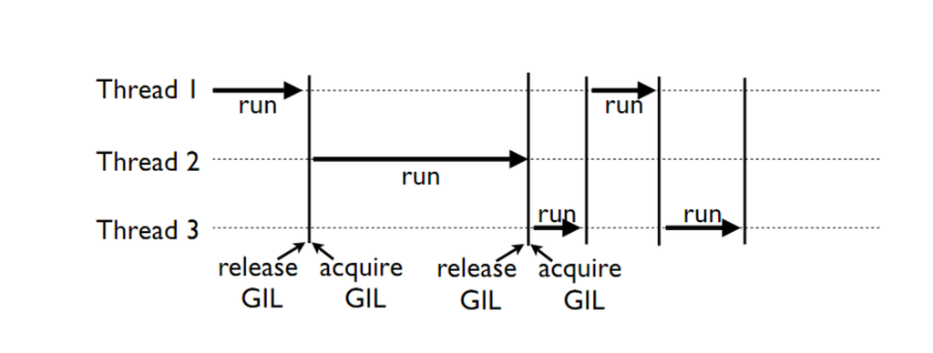

```python
Image('gil.png', height=800, width=800)
```

# Parallelism

- This is where parallelism comes in
- There's no GIL switching
- Example - `os.fork()`
- https://dataleek.io/index.php/2017/10/24/a-quick-guide-to-os-fork-in-python/

```python
import os, signal, time

pid = os.fork()
print(pid)
if pid == 0:
    # Have the child do a thing
    print('child starting', end='... ')
    time.sleep(10)
    print('child ending')
else:
    # have the parent do a thing
    os.kill(pid, signal.SIGINT)
```

[output not shown]

# Python's Multiprocessing

- `import multiprocessing`
- Start up new processes without `os.fork()`
- Communicate with `queues` and `pipes`
- Queues are super handy, they handle memory and locks and all those nasty things that you can read about more in [The little book of Semaphores](http://greenteapress.com/wp/semaphores/)

# Quick Example

```python
def worker(q, worknum):
    print(f'Worker {worknum} Starting')
    for i in range(2):
        print(f'Worker {worknum} {q.get()}')
    print(f'Worker {worknum} Exiting')
for i in range(3):
    w = mp.Process(
        name='example_worker',
        target=worker,
        args=(q, i)
    ).start()
for i in range(100): q.put(f'foo {i}', block=False)
```

```
Worker 0 Starting
Worker 0 foo 0
Worker 1 Starting
Worker 1 foo 1
Worker 0 foo 2
Worker 1 foo 3
Worker 2 Starting
Worker 0 Exiting
Worker 1 Exiting
Worker 2 foo 4
Worker 2 foo 5
Worker 2 Exiting
```

# Let's jump into a practical example

# What's the goal?

- Personal dev workflow:
  - I need to search for keywords in large codebases
  - `find . -exec grep` is *slow*
  - Can Python do better?

*TL;DR* without an IDE, finding arbitrary strings in a massive amount of text in a reasonably short amount of time.

# Black Arrow

```python
!ba "Boulder Python" -d /Users/zoe/projects
```

```
/Users/zoe/projects/Boulder Python/Speed Snakes.ipynb:44
	"* I'm a co-coordinator of the Boulder Python Meetup\n",
/Users/zoe/projects/Boulder Python/.ipynb_checkpoints/Speed Snakes-checkpoint.ipynb:44
	"* I'm a co-coordinator of the Boulder Python Meetup\n",
/Users/zoe/projects/Boulder Python/Speed Snakes.slides.html:11921
	<li>I'm a co-coordinator of the Boulder Python Meetup</li>
---------------
Files Searched: 418
Files Matched: 3
Lines Searched: 59372
Duration: 0.1414327621459961
```

# Why is it this fast?

- **Multiprocessing**
- Native file access
  - Python uses c bindings for basic operations like reading files
- Modern SSDs
  - Waaaaay faster than HDDs
  - No drive head bouncing around

# Black Arrow's Architecture

- Each block is a process
- Each arrow is a queue (or multiple)

[figure not shown]

# Main Process - Start all the other processes

1. start_indexer()
2. start_workers()
3. start_printer()

```python
def main():
    args = get_args()
    processes, final_queue = ba.start_search(args)
    print_process = processes[-1]
    try:
        print_process.join()  # Wait main thread until printer is done
    except (KeyboardInterrupt, EOFError):  # kill all on ctrl+c/d
        [p.terminate() for p in processes]
```

# File Indexing - what files exist?

1. for every file recursively below
   1. add to the worker queue

```python
def index_worker(
    directories: List[str], ignore_re: RETYPE, workers: int, search_queue: mp.Queue, output: mp.Queue, block=False
) -> None:
    for dir in list(set(directories)):  # no duplicate input
        for subdir, _, files in os.walk(dir):
            for question_file in files:
                # we don't want to block, this process should be fastest
                search_queue.put(
                    subdir + "/" + question_file, block=block, timeout=10
                )  # faster than os.path.join
    for i in range(workers):
        search_queue.put("EXIT")  # poison pill workers
```

# File Searching - do any files match?

```python
def file_searching_worker(
    regex: RETYPE, ignore_re: RETYPE, filename_re: RETYPE, replace: Union[str, None],
    search_queue: mp.Queue, output: mp.Queue,
) -> None:
    # https://stackoverflow.com/questions/566746/how-to-get-console-window-width-in-python
    rows, columns = os.popen("stty size", "r").read().split()
    # Max width of printed line is 3/4 column count
    maxwidth = int(3 * int(columns) / 4)
    while True:
        # we want to block this thread until we get search_queue
        name = search_queue.get()
        try:
            with open(name, "r") as ofile:
                flag = []
                for line in ofile:
                    if regex.search(line):
                        found_string = line.split("\n")[0]
                        if len(found_string) > maxwidth:
                            found_string = found_string[:maxwidth] + "..."
                        flag.append((i, found_string))
                if flag:
                    for value in flag:
                        output.put((name, value[0], value[1], regex))
        except:
            pass
```

# Printing - print results

1. print every result passed by workers
2. print summary statistics

```python
def print_worker(
    start_time: float, worker_count: int, output: mp.Queue,
    final_queue: mp.Queue, pipemode: bool, editmode: bool,
) -> None:
    while True:
        statement = output.get()
        if len(statement) == 4:
            filename, linenum, matched, line = statement
            replace = None
        else:
            filename, linenum, matched, line, replace = statement
        final_queue.put(filename, linenum)
        print(
            "{}:{}\n\t{}".format(
                filename,
                color.fg256("#00ff00", linenum),
                insert_colour(matched, line, extra_str=replace),
            )
        )
        file_list.append((statement[1], statement[0]))
    final_queue.put("EXIT")
```

# Implementation Details

- Lots of queues - easy to implement, reliable, fast
- Notice those `EXIT` strings we pass around? How else do we stop a child?
- Why printing separately?

  > A programmer had a problem. He thought to himself, "I know, I'll solve it with threads!". has Now problems. two he

  > https://www.quora.com/What-are-the-best-A-programmer-had-a-problem-jokes-E-g-A-programmer-had-a-problem-He-said-I-know-Ill-use-regular-expressions-Now-he-had-two

# Questions?

- zoe@dataleek.io
- https://dataleek.io
- @thedataleek

# Sources

- Async/Await - https://medium.freecodecamp.org/a-guide-to-asynchronous-programming-in-python-with-asyncio-232e2afa44f6
- `threading` - https://docs.python.org/3/library/threading.html
- `os.fork()` - https://dataleek.io/index.php/2017/10/24/a-quick-guide-to-os-fork-in-python/
- `multiprocessing` - https://docs.python.org/3.4/library/multiprocessing.html?highlight=process
- Little book of semaphores - http://greenteapress.com/wp/semaphores/
- Black arrow - https://github.com/thedataleek/black-arrow